# Dada2_report

Ramón Gallego

1/9/2018

## Dada2 report

You have successfully split your libraries into a pair (or two) of fastq files per sample. Now let’s import the output of demultiplex_both_fastq.sh

First load the packages. And let’s update the parameters we need

```
## # A tibble: 6 x 3
##   Full_Id                            fastq_header  Sample
##   <chr>                              <chr>         <chr>
## 1 ID1=Lib_13;ID2A=ACATGT;ID2B=ACATGT Lib_13_ACATGT WB_Al_01_May_17_r1_27.1
## 2 ID1=Lib_13;ID2A=GCAGTG;ID2B=CACTGC Lib_13_GCAGTG WB_Eg_00_May_17_r1_28.1
## 3 ID1=Lib_13;ID2A=ATCAGT;ID2B=ACTGAT Lib_13_ATCAGT WB_Al_15_Jul_17_r1_67.1
## 4 ID1=Lib_13;ID2A=GTCTCT;ID2B=AGAGAC Lib_13_GTCTCT WB_Al_10_Jul_17_r1_68.1
## 5 ID1=Lib_13;ID2A=ACACAC;ID2B=GTGTGT Lib_13_ACACAC WB_Eg_00_Jul_17_r1_70.1
## 6 ID1=Lib_13;ID2A=TCGCAT;ID2B=ATGCGA Lib_13_TCGCAT WB_Al_10_Aug_17_r1_128.1
```

```
## [1] "/Users/ramongallego/EJP_20190207/Lib-B_S2_L001_R1_001.fastq"
```

Firstly, we’ll find the patterns that separate our Fwd, Rev, .1 and .2 files. look at the quality of the .1 and .2 reads

```r
F1s <- sort(list.files(path1, pattern="_Fwd.1.fastq", full.names = TRUE))
F2s <- sort(list.files(path1, pattern="_Fwd.2.fastq", full.names = TRUE))
R1s <- sort(list.files(path1, pattern="_Rev.1.fastq", full.names = TRUE))
R2s <- sort(list.files(path1, pattern="_Rev.2.fastq", full.names = TRUE))

# Extract sample names, assuming filenames have format: SAMPLENAME_XXX.fastq
sample.names <- str_replace(basename(F1s), "_Fwd.1.fastq","")

#Now use only those that reflect a real sample

good.sample.names<-sample.names[sample.names %in% sample.map$fastq_header]
# Introduce here the biological counterpart of the fastq file

real.sample.name <- sample.map[,3][match(good.sample.names,sample.map$fastq_header),1]

# Now subset the number of files to be looked at

F1sgood<-F1s[sample.names %in% sample.map$fastq_header]
F2sgood<-F2s[sample.names %in% sample.map$fastq_header]
R1sgood<-R1s[sample.names %in% sample.map$fastq_header]
R2sgood<-R2s[sample.names %in% sample.map$fastq_header]
```

A nice idea is to plot the Quality of the F1 reads

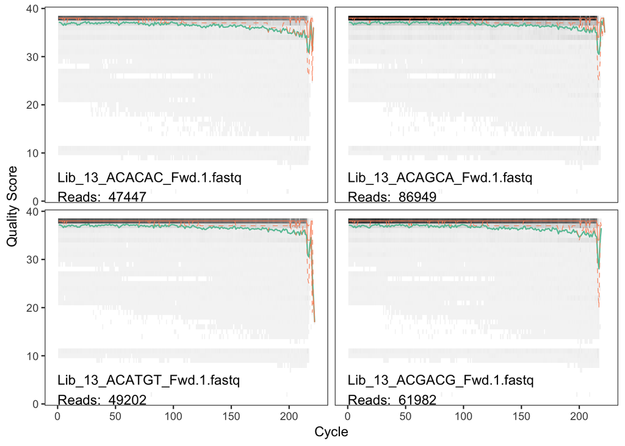

The quality should be similar to that of the Reverse .1 reads

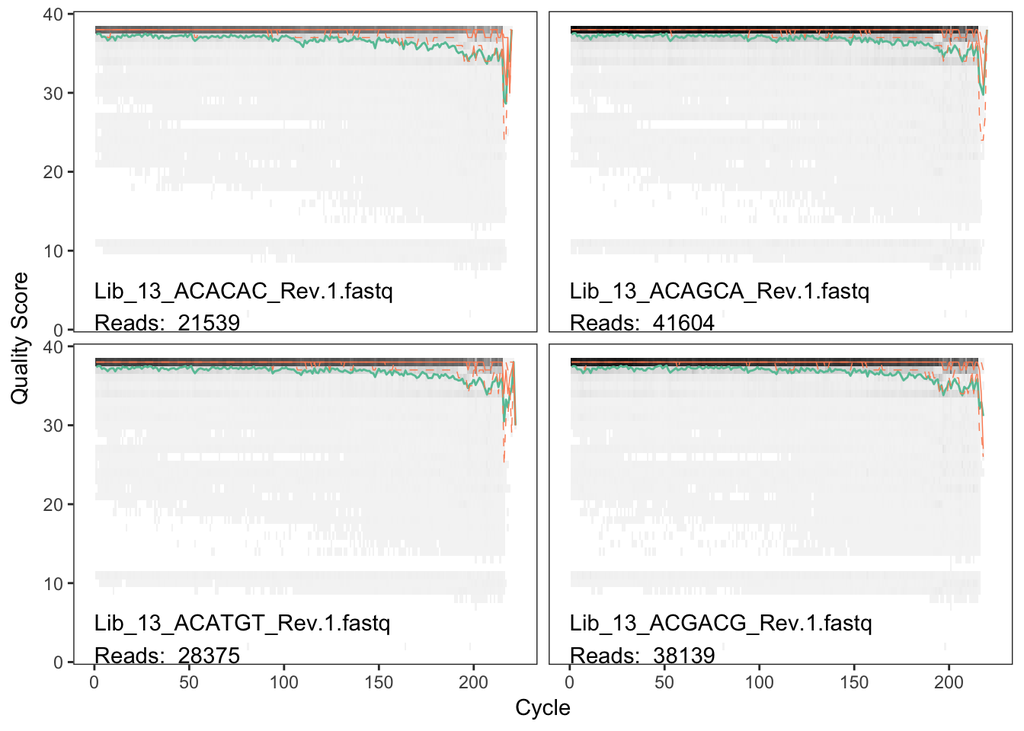

On the other hand, the quality of the .2 reads should decrease earlier

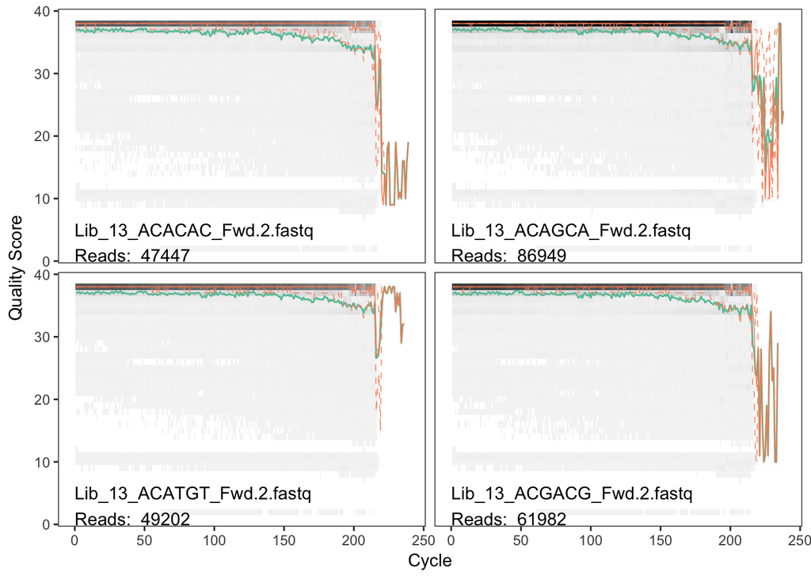

## Now start with the trimming of each read based on the quality we just plotted

```r
filt_path <- file.path(params$folder, "/filtered") # Place filtered files in filtered/ subdirectory
filtF1s <- file.path(filt_path, paste0(good.sample.names, "_F1_filt.fastq.gz"))
filtF2s <- file.path(filt_path, paste0(good.sample.names, "_F2_filt.fastq.gz"))
out_Fs <- filterAndTrim(F1sgood, filtF1s, F2sgood, filtF2s, truncLen=c(200,200),
                      maxN=0, maxEE=c(2,2), truncQ=2, rm.phix=TRUE,
                      compress=TRUE, multithread=TRUE) # On Windows set multithread=FALSE
```

```
## Creating output directory: /Users/ramongallego/fastqs_demultiplexed_for_DADA2/demultiplexed_20190212_1345//filtered
```

```r
filtR1s <- file.path(filt_path, paste0(good.sample.names, "_R1_filt.fastq.gz"))
filtR2s <- file.path(filt_path, paste0(good.sample.names, "_R2_filt.fastq.gz"))
out_Rs <- filterAndTrim(R1sgood, filtR1s, R2sgood, filtR2s, truncLen=c(200,200),
                      maxN=0, maxEE=c(2,2), truncQ=2, rm.phix=TRUE,
                      compress=TRUE, multithread=TRUE)
```

```r
out_Fs_tibble<-tibble(file=dimnames(out_Fs)[[1]], reads.out=out_Fs[,2])
out_Rs_tibble<-tibble(file=dimnames(out_Rs)[[1]], reads.out=out_Rs[,2])
out_Fs_tibble
```

```
## # A tibble: 93 x 2
##    file                      reads.out
##    <chr>                         <dbl>
##  1 Lib_13_ACACAC_Fwd.1.fastq     41969
##  2 Lib_13_ACAGCA_Fwd.1.fastq     80288
##  3 Lib_13_ACATGT_Fwd.1.fastq     42750
##  4 Lib_13_ACGACG_Fwd.1.fastq     51548
##  5 Lib_13_ATATCG_Fwd.1.fastq     29796
##  6 Lib_13_ATCAGT_Fwd.1.fastq     92000
##  7 Lib_13_CGACGC_Fwd.1.fastq     73635
##  8 Lib_13_CTCGCA_Fwd.1.fastq     71683
##  9 Lib_13_GATGAC_Fwd.1.fastq     60669
## 10 Lib_13_GCAGTG_Fwd.1.fastq     54092
## # ... with 83 more rows
```

Now the first crucial step: learning the error rates that would be different for fwd and rev reads

```r
errF1 <- learnErrors(filtF1s, multithread=TRUE,verbose = 0)
errF2 <- learnErrors(filtF2s, multithread=TRUE,verbose = 0)
errR1 <- learnErrors(filtR1s, multithread=TRUE,verbose = 0)
errR2 <- learnErrors(filtR2s, multithread=TRUE,verbose = 0)

# Write errors to csv to see if they matter at all
tosave <- list(errF1, errF2, errR1, errR2)

saveRDS(tosave, file = "all.errors.rds")
```

Which we can plot now to see the error rates between transitions of each pair of nt

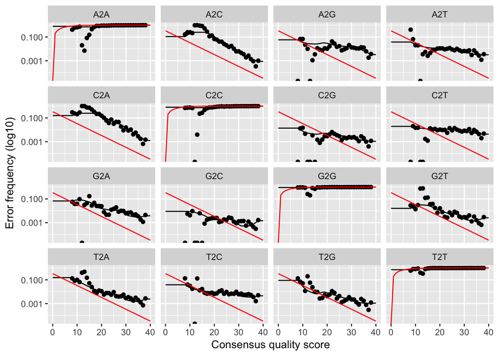

```r
plotErrors(errF1, nominalQ = T)
```

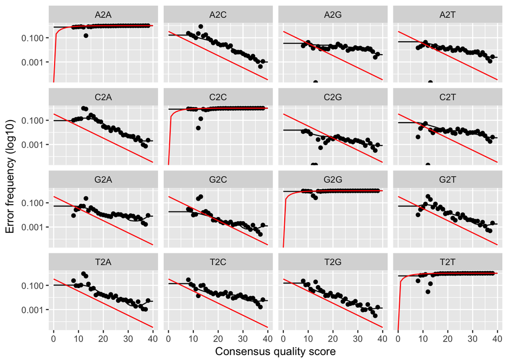

```r
plotErrors(errF2, nominalQ = T)
```

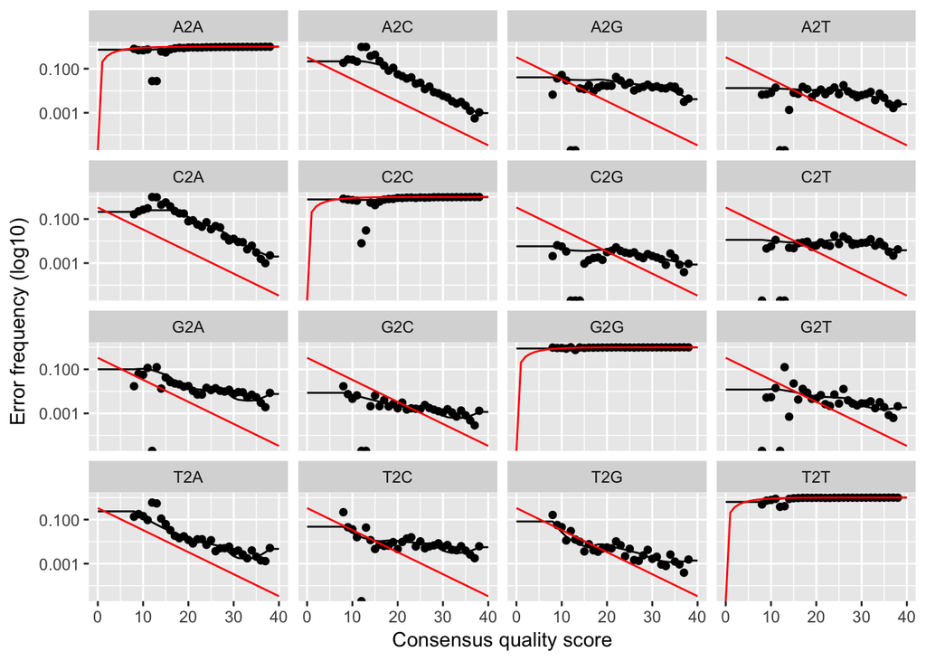

```r
plotErrors(errR1, nominalQ = T)
```

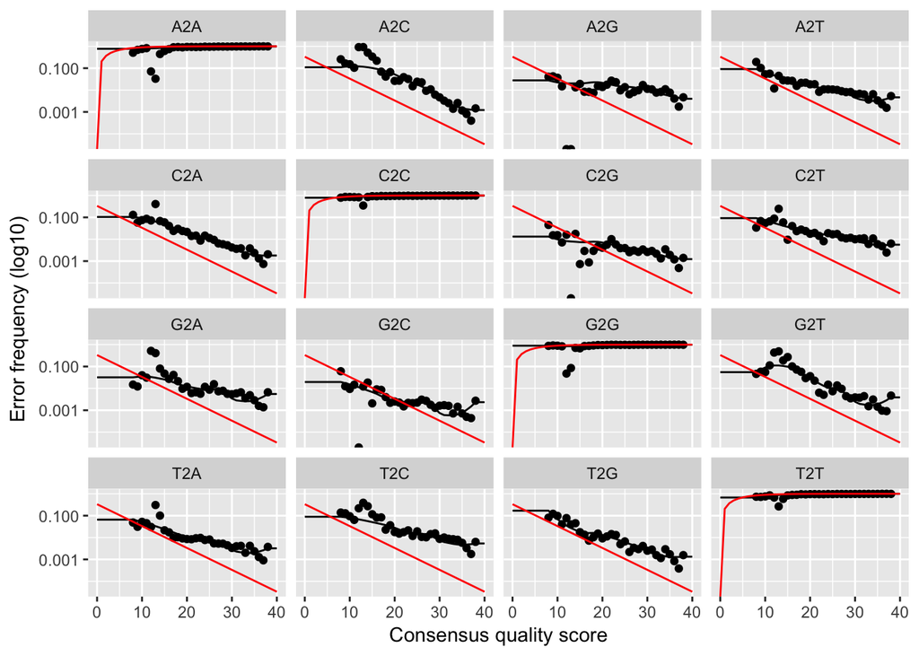

```r
plotErrors(errR2, nominalQ = T)
```

## Now go to the dereplication step

## And finally an inference of the sample composition

```r
dadaF1s <- dada(derepF1s, err = errF1, multithread = TRUE)
```

```
## Sample 1 - 41969 reads in 16724 unique sequences.
## Sample 2 - 80288 reads in 25962 unique sequences.
## Sample 3 - 42750 reads in 17321 unique sequences.
## Sample 4 - 51548 reads in 19701 unique sequences.
## Sample 5 - 29796 reads in 6907 unique sequences.
## Sample 6 - 92000 reads in 31231 unique sequences.
## Sample 7 - 73635 reads in 33201 unique sequences.
## Sample 8 - 71683 reads in 21413 unique sequences.
## Sample 9 - 60669 reads in 21027 unique sequences.
## Sample 10 - 54092 reads in 20477 unique sequences.
## Sample 11 - 63158 reads in 22294 unique sequences.
## Sample 12 - 68168 reads in 22028 unique sequences.
## Sample 13 - 59793 reads in 22982 unique sequences.
## Sample 14 - 26155 reads in 8249 unique sequences.
## Sample 15 - 3080 reads in 931 unique sequences.
## Sample 16 - 61074 reads in 22864 unique sequences.
## Sample 17 - 74517 reads in 23758 unique sequences.
## Sample 18 - 61637 reads in 20403 unique sequences.
## Sample 19 - 68859 reads in 28370 unique sequences.
## Sample 20 - 61286 reads in 22317 unique sequences.
## Sample 21 - 65119 reads in 22728 unique sequences.
## Sample 22 - 51340 reads in 15344 unique sequences.
## Sample 23 - 65967 reads in 17632 unique sequences.
## Sample 24 - 42956 reads in 17192 unique sequences.
## Sample 25 - 60155 reads in 17408 unique sequences.
## Sample 26 - 87091 reads in 29325 unique sequences.
## Sample 27 - 49831 reads in 15065 unique sequences.
## Sample 28 - 47572 reads in 14331 unique sequences.
## Sample 29 - 79548 reads in 23898 unique sequences.
## Sample 30 - 58014 reads in 21114 unique sequences.
## Sample 31 - 53552 reads in 19308 unique sequences.
## Sample 32 - 60472 reads in 23158 unique sequences.
## Sample 33 - 55491 reads in 18937 unique sequences.
## Sample 34 - 57266 reads in 17851 unique sequences.
## Sample 35 - 55483 reads in 23207 unique sequences.
## Sample 36 - 66874 reads in 20724 unique sequences.
## Sample 37 - 74115 reads in 22441 unique sequences.
## Sample 38 - 69121 reads in 25342 unique sequences.
## Sample 39 - 67636 reads in 27375 unique sequences.
## Sample 40 - 63435 reads in 25299 unique sequences.
```

[output cut: 38 more lines]

```
## Sample 79 - 44707 reads in 16906 unique sequences.
## Sample 80 - 35506 reads in 10748 unique sequences.
## Sample 81 - 53639 reads in 15064 unique sequences.
## Sample 82 - 49248 reads in 19459 unique sequences.
## Sample 83 - 52882 reads in 19764 unique sequences.
## Sample 84 - 57388 reads in 23129 unique sequences.
## Sample 85 - 70898 reads in 27573 unique sequences.
## Sample 86 - 65096 reads in 23936 unique sequences.
## Sample 87 - 49601 reads in 18498 unique sequences.
## Sample 88 - 69554 reads in 21390 unique sequences.
## Sample 89 - 53153 reads in 21004 unique sequences.
## Sample 90 - 79651 reads in 26414 unique sequences.
## Sample 91 - 63724 reads in 20418 unique sequences.
## Sample 92 - 50714 reads in 16266 unique sequences.
## Sample 93 - 58068 reads in 20022 unique sequences.
```

```r
dadaF2s <- dada(derepF2s, err = errF2, multithread = TRUE)
```

```
## Sample 1 - 41969 reads in 16394 unique sequences.
## Sample 2 - 80288 reads in 24494 unique sequences.
## Sample 3 - 42750 reads in 16790 unique sequences.
## Sample 4 - 51548 reads in 18328 unique sequences.
## Sample 5 - 29796 reads in 6219 unique sequences.
## Sample 6 - 92000 reads in 30321 unique sequences.
## Sample 7 - 73635 reads in 32240 unique sequences.
## Sample 8 - 71683 reads in 21199 unique sequences.
## Sample 9 - 60669 reads in 20613 unique sequences.
## Sample 10 - 54092 reads in 20704 unique sequences.
## Sample 11 - 63158 reads in 22354 unique sequences.
## Sample 12 - 68168 reads in 21604 unique sequences.
## Sample 13 - 59793 reads in 22350 unique sequences.
## Sample 14 - 26155 reads in 8779 unique sequences.
## Sample 15 - 3080 reads in 913 unique sequences.
## Sample 16 - 61074 reads in 22032 unique sequences.
## Sample 17 - 74517 reads in 23465 unique sequences.
## Sample 18 - 61637 reads in 20739 unique sequences.
## Sample 19 - 68859 reads in 27578 unique sequences.
## Sample 20 - 61286 reads in 21396 unique sequences.
## Sample 21 - 65119 reads in 22267 unique sequences.
## Sample 22 - 51340 reads in 15785 unique sequences.
## Sample 23 - 65967 reads in 16935 unique sequences.
## Sample 24 - 42956 reads in 16842 unique sequences.
## Sample 25 - 60155 reads in 17290 unique sequences.
## Sample 26 - 87091 reads in 29011 unique sequences.
## Sample 27 - 49831 reads in 15857 unique sequences.
## Sample 28 - 47572 reads in 14748 unique sequences.
## Sample 29 - 79548 reads in 23866 unique sequences.
## Sample 30 - 58014 reads in 19573 unique sequences.
## Sample 31 - 53552 reads in 19438 unique sequences.
## Sample 32 - 60472 reads in 23251 unique sequences.
## Sample 33 - 55491 reads in 19652 unique sequences.
## Sample 34 - 57266 reads in 18975 unique sequences.
## Sample 35 - 55483 reads in 23198 unique sequences.
## Sample 36 - 66874 reads in 20648 unique sequences.
## Sample 37 - 74115 reads in 24521 unique sequences.
## Sample 38 - 69121 reads in 24349 unique sequences.
## Sample 39 - 67636 reads in 25991 unique sequences.
## Sample 40 - 63435 reads in 24887 unique sequences.
```

[output cut: 38 more lines]

```
## Sample 79 - 44707 reads in 16003 unique sequences.
## Sample 80 - 35506 reads in 10849 unique sequences.
## Sample 81 - 53639 reads in 15081 unique sequences.
## Sample 82 - 49248 reads in 18007 unique sequences.
## Sample 83 - 52882 reads in 19462 unique sequences.
## Sample 84 - 57388 reads in 23211 unique sequences.
## Sample 85 - 70898 reads in 26106 unique sequences.
## Sample 86 - 65096 reads in 22375 unique sequences.
## Sample 87 - 49601 reads in 18158 unique sequences.
## Sample 88 - 69554 reads in 21568 unique sequences.
## Sample 89 - 53153 reads in 19531 unique sequences.
## Sample 90 - 79651 reads in 27082 unique sequences.
## Sample 91 - 63724 reads in 20446 unique sequences.
## Sample 92 - 50714 reads in 16233 unique sequences.
## Sample 93 - 58068 reads in 19947 unique sequences.
```

```r
dadaR1s <- dada(derepR1s, err = errR1, multithread = TRUE)
```

```
## Sample 1 - 18677 reads in 8289 unique sequences.
## Sample 2 - 38290 reads in 13432 unique sequences.
## Sample 3 - 24260 reads in 10265 unique sequences.
## Sample 4 - 30999 reads in 11922 unique sequences.
## Sample 5 - 16013 reads in 3735 unique sequences.
## Sample 6 - 58504 reads in 21048 unique sequences.
## Sample 7 - 48466 reads in 22150 unique sequences.
## Sample 8 - 38013 reads in 12478 unique sequences.
## Sample 9 - 25575 reads in 10088 unique sequences.
## Sample 10 - 52701 reads in 19346 unique sequences.
## Sample 11 - 36392 reads in 13955 unique sequences.
## Sample 12 - 40370 reads in 14494 unique sequences.
## Sample 13 - 32591 reads in 13663 unique sequences.
## Sample 14 - 10246 reads in 4303 unique sequences.
## Sample 15 - 1458 reads in 573 unique sequences.
## Sample 16 - 27097 reads in 11161 unique sequences.
## Sample 17 - 35416 reads in 13278 unique sequences.
## Sample 18 - 37187 reads in 13521 unique sequences.
## Sample 19 - 40982 reads in 17640 unique sequences.
## Sample 20 - 30298 reads in 12312 unique sequences.
## Sample 21 - 41725 reads in 15699 unique sequences.
## Sample 22 - 27995 reads in 9718 unique sequences.
## Sample 23 - 27220 reads in 8885 unique sequences.
## Sample 24 - 40838 reads in 15624 unique sequences.
## Sample 25 - 34353 reads in 11487 unique sequences.
## Sample 26 - 49707 reads in 18181 unique sequences.
## Sample 27 - 27760 reads in 10242 unique sequences.
## Sample 28 - 25736 reads in 9417 unique sequences.
## Sample 29 - 32495 reads in 11739 unique sequences.
## Sample 30 - 29988 reads in 11623 unique sequences.
## Sample 31 - 24246 reads in 9859 unique sequences.
## Sample 32 - 27261 reads in 11712 unique sequences.
## Sample 33 - 31260 reads in 11857 unique sequences.
## Sample 34 - 33152 reads in 11535 unique sequences.
## Sample 35 - 26662 reads in 12437 unique sequences.
## Sample 36 - 42535 reads in 13822 unique sequences.
## Sample 37 - 46810 reads in 16594 unique sequences.
## Sample 38 - 35592 reads in 13897 unique sequences.
## Sample 39 - 26786 reads in 12316 unique sequences.
## Sample 40 - 57913 reads in 22143 unique sequences.
```

[output cut: 38 more lines]

```
## Sample 79 - 21568 reads in 8790 unique sequences.
## Sample 80 - 20786 reads in 7209 unique sequences.
## Sample 81 - 31933 reads in 10171 unique sequences.
## Sample 82 - 24687 reads in 10707 unique sequences.
## Sample 83 - 34587 reads in 13793 unique sequences.
## Sample 84 - 37752 reads in 16329 unique sequences.
## Sample 85 - 37910 reads in 15655 unique sequences.
## Sample 86 - 27656 reads in 10940 unique sequences.
## Sample 87 - 49055 reads in 17594 unique sequences.
## Sample 88 - 40704 reads in 14842 unique sequences.
## Sample 89 - 31427 reads in 12919 unique sequences.
## Sample 90 - 48319 reads in 17621 unique sequences.
## Sample 91 - 36752 reads in 12954 unique sequences.
## Sample 92 - 21216 reads in 8379 unique sequences.
## Sample 93 - 29965 reads in 11875 unique sequences.
```

```r
dadaR2s <- dada(derepR2s, err = errR2, multithread = TRUE)
```

```
## Sample 1 - 18677 reads in 8354 unique sequences.
## Sample 2 - 38290 reads in 14192 unique sequences.
## Sample 3 - 24260 reads in 10613 unique sequences.
## Sample 4 - 30999 reads in 12973 unique sequences.
## Sample 5 - 16013 reads in 4176 unique sequences.
## Sample 6 - 58504 reads in 22032 unique sequences.
## Sample 7 - 48466 reads in 23678 unique sequences.
## Sample 8 - 38013 reads in 13259 unique sequences.
## Sample 9 - 25575 reads in 10419 unique sequences.
## Sample 10 - 52701 reads in 19726 unique sequences.
## Sample 11 - 36392 reads in 14617 unique sequences.
## Sample 12 - 40370 reads in 14585 unique sequences.
## Sample 13 - 32591 reads in 14133 unique sequences.
## Sample 14 - 10246 reads in 3920 unique sequences.
## Sample 15 - 1458 reads in 489 unique sequences.
## Sample 16 - 27097 reads in 11451 unique sequences.
## Sample 17 - 35416 reads in 13515 unique sequences.
## Sample 18 - 37187 reads in 13635 unique sequences.
## Sample 19 - 40982 reads in 18627 unique sequences.
## Sample 20 - 30298 reads in 12697 unique sequences.
## Sample 21 - 41725 reads in 16006 unique sequences.
## Sample 22 - 27995 reads in 9584 unique sequences.
## Sample 23 - 27220 reads in 8796 unique sequences.
## Sample 24 - 40838 reads in 16837 unique sequences.
## Sample 25 - 34353 reads in 11545 unique sequences.
## Sample 26 - 49707 reads in 18926 unique sequences.
## Sample 27 - 27760 reads in 9638 unique sequences.
## Sample 28 - 25736 reads in 9009 unique sequences.
## Sample 29 - 32495 reads in 11906 unique sequences.
## Sample 30 - 29988 reads in 12338 unique sequences.
## Sample 31 - 24246 reads in 10149 unique sequences.
## Sample 32 - 27261 reads in 12092 unique sequences.
## Sample 33 - 31260 reads in 12056 unique sequences.
## Sample 34 - 33152 reads in 11747 unique sequences.
## Sample 35 - 26662 reads in 12939 unique sequences.
## Sample 36 - 42535 reads in 14624 unique sequences.
## Sample 37 - 46810 reads in 16396 unique sequences.
## Sample 38 - 35592 reads in 15233 unique sequences.
## Sample 39 - 26786 reads in 12549 unique sequences.
## Sample 40 - 57913 reads in 23616 unique sequences.
```

[output cut: 38 more lines]

```
## Sample 79 - 21568 reads in 9403 unique sequences.
## Sample 80 - 20786 reads in 6888 unique sequences.
## Sample 81 - 31933 reads in 9811 unique sequences.
## Sample 82 - 24687 reads in 11176 unique sequences.
## Sample 83 - 34587 reads in 14012 unique sequences.
## Sample 84 - 37752 reads in 16453 unique sequences.
## Sample 85 - 37910 reads in 16776 unique sequences.
## Sample 86 - 27656 reads in 11569 unique sequences.
## Sample 87 - 49055 reads in 18149 unique sequences.
## Sample 88 - 40704 reads in 15062 unique sequences.
## Sample 89 - 31427 reads in 13951 unique sequences.
## Sample 90 - 48319 reads in 18000 unique sequences.
## Sample 91 - 36752 reads in 13625 unique sequences.
## Sample 92 - 21216 reads in 8069 unique sequences.
## Sample 93 - 29965 reads in 11987 unique sequences.
```

## We are ready now to merge reads - using the denoised reads and the derep files.

We will start by saving all files to disk.

```r
tosave <- list(derepF1s, derepF2s, derepR1s, derepR2s, dadaF1s, dadaF2s, dadaR1s,dadaR2s)

   saveRDS(tosave, file = "tosave.rds")
```

The pipeline breaks if for some reason there are samples that don’t have any reads passing filters (or at least that is the current hypothesis)

```r
to.keep.F <- map_lgl(dadaF1s, ~(sum(.x$denoised) > 150)) # Which samples have more than 150 reads passing filters in the Fwd direction
to.keep.R <- map_lgl(dadaR1s, ~(sum(.x$denoised) > 150)) #  Which samples have more than 150 reads passing filters in the Rev direction

to.keep <- (to.keep.F + to.keep.R) == 2 # Keep only those that pass boths filters

mergersF <- mergePairs(dadaF1s[to.keep],
   derepF1s[to.keep],
   dadaF2s[to.keep],
   derepF2s[to.keep],
   verbose = 0)

#Run a for loop that adds the number of unique reads that went into each ASV

for (j in 1:length(mergersF)){

  dadaF1s[[j]]@.Data[[2]] %>% rownames_to_column(var="forward") %>% select("forward", "nunq") ->Fwd
  Fwd$forward<-as.integer(Fwd$forward)
  dadaF2s[[j]]@.Data[[2]] %>% rownames_to_column(var="reverse") %>% select("reverse", "nunq") ->Rev
  Rev$reverse<-as.integer(Rev$reverse)

  mergersF[[j]] <- left_join(mergersF[[j]],Fwd, by="forward") %>% left_join(Rev, by="reverse") %>% mutate(nunq=pmin(nunq.x,nunq.y)) %>% select(-nunq.x,-nunq.y)


}
mergersR <- mergePairs(dadaR1s[to.keep],
   derepR1s[to.keep],
   dadaR2s[to.keep],
   derepR2s[to.keep],
   verbose = 0)

for (j in 1:length(mergersR)){

  dadaR1s[[j]]@.Data[[2]] %>% rownames_to_column(var="forward") %>% select("forward", "nunq") ->Fwd
  Fwd$forward<-as.integer(Fwd$forward)
  dadaR2s[[j]]@.Data[[2]] %>% rownames_to_column(var="reverse") %>% select("reverse", "nunq") ->Rev
  Rev$reverse<-as.integer(Rev$reverse)

  mergersR[[j]] <- left_join(mergersR[[j]],Fwd, by="forward") %>% left_join(Rev, by="reverse") %>% mutate(nunq=pmin(nunq.x,nunq.y)) %>% select(-nunq.x,-nunq.y)

}
```

## Now we have to merge the Forward and Reverse Reads to make a unique object

Step 1 is to create sequence tables for each direction, seqtabF and seqtabR

```r
seqtabF <- makeSequenceTable(mergersF)
```

```
## The sequences being tabled vary in length.
```

```r
dim(seqtabF)
```

```
## [1]    92 12289
```

```r
table(nchar(getSequences(seqtabF)))
```

```
##
##   201   202   203   204   205   207   209   212   213   214   215   216
##     3     3     1     2     2     1     1     3     1     2     1     1
##   218   223   226   227   228   229   233   234   236   238   239   242
##     4     2     1     4     1     6     1     1     1     1     3     7
##   243   244   249   251   252   253   254   256   257   258   259   261
##     1     1     1     1     1     1     1     4     1     1     3     1
##   262   264   265   266   267   269   271   279   282   285   295   296
##     2     4     1     2    12     2     1     1     1     1     5     3
##   299   300   301   302   303   304   305   306   307   308   309   310
##     1     1     8     4     2    30     6     3    41    67    69    56
##   311   312   313   314   315   316   319   322   328   331   343   348
##    52   476 10432     1     7   138   424     1     1     3     1     1
##   349   350   351   352   354   355   358   369   370
##    10     2     8   284     1    50     1     1     2
```

```r
seqtabR <- makeSequenceTable(mergersR)
```

```
## The sequences being tabled vary in length.
```

```r
dim(seqtabR)
```

```
## [1]   92 7350
```

```r
table(nchar(getSequences(seqtabR)))
```

```
##
##  200  201  203  204  205  207  208  209  213  214  218  221  226  227  229
##    1    3    2    1    1    2    1    1    2    2    1    1    1    1    2
##  231  238  239  242  249  251  253  256  257  259  264  265  267  268  269
##    1    2    2    3    1    1    1    4    1    2    1    1    6    1    1
##  296  297  301  302  303  304  305  306  307  308  309  310  311  312  313
##    1    1    6    4    1   22    3    3   24   40   37   37   45  258 6195
##  315  316  319  328  331  336  349  351  352  354  355  358  369  370
##    5   98  287    1    1    1    5    6  182    1   33    1    1    1
```

Step 2 is to reverse complement the reverse reads, and checking how many of the reads in F were present in R (if you get a 0 means we have done something wrong). Lastly, we change the reverse sequences and add their Reverse complement instead

```r
reversed_sequences<-as.character(reverseComplement(DNAStringSet(colnames(seqtabR))))

summary (colnames(seqtabF) %in% reversed_sequences)
```

```
##    Mode   FALSE    TRUE
## logical    7018    5271
```

```r
summary (reversed_sequences %in% colnames(seqtabF))
```

```
##    Mode   FALSE    TRUE
## logical    2079    5271
```

```r
colnames(seqtabR)<-reversed_sequences
```

Step 3 does the actual merging and returns another sequence Table

```r
seqtab.R.df=as.data.frame(seqtabR)

final.seqtab<-data.frame(row.names = rownames(seqtabF))


for (i in 1:ncol(seqtabF)) {   #for each column of the first dataframe

  current_seq<-colnames(seqtabF)[i]

  if (current_seq %in% colnames(seqtab.R.df)) { # is that column present on the second df?

    final.seqtab[,current_seq]<-seqtabF[,i] + seqtab.R.df[,current_seq] #if yes, the new df has the sum of reads

    seqtab.R.df[,current_seq]<-NULL
    #seqtab.R2.df<- seqtab.R2.df[,-current_seq] #we delete the column from the second df to speed up next search


  } else {        # if the column is not present, then the new df is the value of the first df

    final.seqtab[,current_seq] <- seqtabF[,i]

  }



}
# Now cbind both dataset
final.seqtab <- as.matrix (cbind(final.seqtab,seqtab.R.df))
```

## Now get rid of the chimeras

```r
seqtab.nochim <- removeBimeraDenovo(final.seqtab, method="consensus", multithread=TRUE)

dim(seqtab.nochim)
```

```
## [1]   92 5167
```

## Now it is a good time to check whether the sequences are in the Fwd or Reverse-ReverseComplement direction, we’ll use 500 sequences to make up our test

```r
ifelse(length(colnames(seqtab.nochim))>500, to_write<- sample(colnames(seqtab.nochim),size = 500, replace = F), to_write<-colnames(seqtab.nochim))
```

```
## [1] "CTTAGCCAAAACTTAGCGCATAGCGGGAGGTCTGTAGATTTTGCCATTTTTTCTCTTCAC…"
```

```r
#to_write<- sample(colnames(seqtab.nochim),size = 500, replace = F)
write_lines(to_write, path = "seqnames.txt")
getwd()
```

```
## [1] "/Users/ramongallego/fastqs_demultiplexed_for_DADA2/demultiplexed_20190212_1345"
```

## IF selected, proceed with Hashing: create a hash conversion table and saving files in tidyr format

We are going to keep the info in a tidyr format and save it into a csv file

```r
seqtab.nochim.df=as.data.frame(seqtab.nochim)



# Now decide if you want hashing or not

if (grepl ("yes", params$hash, ignore.case = TRUE)) {

  conv_file = paste0(params$folder,"/hash_key.csv")

  conv_table <- tibble( Hash = "", Sequence ="")

  hashes <- list(NULL)

  for (i in 1:ncol(seqtab.nochim.df)) {   #for each column of the dataframe

    current_seq <-colnames(seqtab.nochim.df)[i]

    current_hash <- digest(current_seq,algo = "sha1",serialize = F,skip = "auto")

    hashes[[i]] = current_hash

    conv_table [i,]<-c(current_hash, current_seq)

    colnames(seqtab.nochim.df)[i] <- current_hash

  }

  write_csv(conv_table, conv_file)


seqtab.nochim.df$sample=rownames(seqtab.nochim.df)

 gather(seqtab.nochim.df, key=Hash, value = nReads, -sample) %>%
  filter(nReads > 0) -> current_asv

write_csv(current_asv, paste0(params$folder,"/ASV_table.csv"))
} else { #What do we do if you don't want hashes: two things - Change the header of the ASV table, write only one file

  seqtab.nochim.df$sample=rownames(seqtab.nochim.df)

  gather(seqtab.nochim.df, key=Sequence, value = nReads, -sample) %>%
   filter(nReads > 0) -> current_asv
  write_csv(current_asv, paste0(params$folder,"/ASV_table.csv"))
}
```

## Track the fate of all reads

```r
getN <- function(x) sum(getUniques(x))
track <- as.data.frame(cbind(out_Fs, out_Rs,
                             sapply(dadaF1s, getN), sapply(dadaR1s, getN),
                             sapply(mergersF, getN),sapply(mergersR, getN),
                             rowSums(seqtabF),rowSums(seqtabR),
                             rowSums(final.seqtab), rowSums(seqtab.nochim)))
# If processing a single sample, remove the sapply calls: e.g. replace sapply(dadaFs, getN) with getN(dadaFs)
colnames(track) <- c("input_F", "input_R", "filtered_F","filtered_R",
                     "denoised_F", "denoised_R",
                     "merged_F", "merged_R",
                     "tabled_F", "tabled_R",
                     "tabled_together", "nonchim")

write_csv(track, paste0(params$folder,"/dada2_summary.csv"))
```

## Merge with a previous analysis if selected

If we have chosen to merge our dataset with a previous run, we need to gather that info, and merge properly both datasets.

```r
if (grepl ("yes", params$cont[1], ignore.case = TRUE)) {

old_hash = read_csv(params$cont[2])

old_asv = read_csv(params$cont[3])

all_hash = union_all(old_hash, conv_table)

new.hashes = setdiff(conv_table,old_hash)

reads.new.hashes <- left_join(new.hashes, current_asv, by = c("Hash" = "Sequence"))

all_asv = bind_rows (old_asv, current_asv)

merging.output = tibble(Date = Sys.Date(), Old_db = params$cont[2], Old_ASV = params$cont[3],
                        Input_folder= params$folder, Nseq_old_db = nrow(old_hash), Nseq_new_input = nrow(conv_table),
                        Nseq_new_db = nrow(all_hash), N_newseq = nrow(new.hashes), Nreads_newseq = sum(reads.new.hashes$nReads) )
ifelse(file.exists(params$cont[4]),
       write_csv(merging.output, params$cont[4], append = T),
       write_csv(merging.output, params$cont[4]) )

write_csv(all_hash, paste0(params$folder, "/Hash_db_",Sys.Date(),".csv"))
write_csv(all_asv, paste0(params$folder, "/ASV_all_",Sys.Date(),".csv"))

}
```